← Eğitim Listesine Geri Dön

# Ölçek Türleri

2025-05-24

ölçek türleri ölçüm düzeyleri veri analiz

# 📏 Ölçek Türleri: Veriyi Nasıl Ölçtüğün, Ne Anlam Çıkardığın Kadardır

## Giriş: Sayılar Her Zaman Aynı Şeyi Göstermez

Diyelim ki bir öğrencinin notu 80.  
Ya da bir kişinin memnuniyet skoru “orta”.  
Ya da sıcaklık -5°C.  
Ya da hız sıfır km/saat.

Bu sayılar farklı şeyleri ifade edebilir.  
Çünkü **ölçek**, verinin anlamını çizer.

## 🔍 Ölçek Nedir?

Ölçek, bir özelliğin **nasıl ölçüldüğünü gösteren yapıdır.**

📌 Örneğin:

- Cinsiyet → adlandırma
- Eğitim durumu → sıralama
- Sıcaklık → eşit aralıklı
- Boy uzunluğu → oranlama

## 🧠 Neden Ölçek Türlerini Bilmeliyiz?

| Sebep | Açıklama |
| --- | --- |
| ✅ **Doğru analiz yapmak için** | Nicel değişkenle ortalama alınır, nitelde mod tercih edilir |
| ✅ **Model seçimi için** | Lojistik regresyon ordinal veride işe yarar mı? |
| ✅ **Yorumlama doğruluğu için** | "2" her zaman "iki kat" anlamına gelmeyebilir |
| ✅ **Veri dönüştürme için** | Kategorik veri sayıya dönüşebilir mi? Nasıl? |

📌 Yanlış ölçekle yapılan analiz → yanlı sonuç  
Ve yanlış yorum → hatalı karar!

## 📐 Dört Ana Ölçek Türü

### 1. **Nominal (Sınıflama)**

- **Anlam:** Farklı sınıfları temsil eder.
- **Matematiksel işlem yok.**
- **Kullanım:** Kategorik veri, etiketleme
- **Örnekler:** Cinsiyet, kan grubu, renk, şehir

#### Python Kodu:

```python
import numpy as np
import pandas as pd

df = pd.read_csv('data/istatistik_ornek.csv')
```

```python
df
```

|  | fiyat | satis_adedi | kategori |
| --- | --- | --- | --- |
| 0 | 218.54 | 15 | Giyim |
| 1 | 477.82 | 12 | Elektronik |
| 2 | 379.40 | 16 | Ev Eşyası |
| 3 | 319.40 | 19 | Giyim |
| 4 | 120.21 | 8 | Giyim |
| ... | ... | ... | ... |
| 995 | 91.21 | 4 | Ev Eşyası |
| 996 | 462.79 | 14 | Ev Eşyası |
| 997 | 111.57 | 9 | Ev Eşyası |
| 998 | 477.61 | 9 | Ev Eşyası |
| 999 | 250.70 | 18 | Elektronik |

1000 rows × 3 columns

```python
print("Nominal değişken örneği:", df['kategori'].unique())
```

```
Nominal değişken örneği: ['Giyim' 'Elektronik' 'Ev Eşyası']
```

📌 Bu veriyle toplama veya çıkarma yapamazsın.  
Sadece **frekans analizi** yapabilirsin.

### 2. **Ordinal (Sıralama)**

- **Anlam:** Sıralama var ama fark yok.
- **Matematiksel işlem:** Sadece büyüklük-küçüklük ilişkisi
- **Kullanım:** Memnuniyet, eğitim düzeyi, pozisyon
- **Örnekler:** “İyi”, “Daha iyi”, “En iyi”  
  ya da “Bekar”, “Evli”, “Boşanmış”

#### Python Kodu:

```python
memnuniyet = pd.Series(['Kötü', 'Orta', 'İyi', 'Çok İyi'])
print("Ordinal değişken örneği:", memnuniyet)
```

```
Ordinal değişken örneği: 0       Kötü
1       Orta
2        İyi
3    Çok İyi
dtype: object
```

### 3. **Interval (Eşit Aralıklı)**

- **Anlam:** Sıfır noktası keyfi.
- **Matematiksel işlem:** Toplama/çıkarma yapılabilir.
- **Kullanım:** Sıcaklık, tarih, IQ skoru
- **Örnekler:** °C, yıl, puan

#### Python Kodu:

```python
sicakliklar = np.array([10, 20, 30])
print("Ortalama sıcaklık:", sicakliklar.mean())
```

```
Ortalama sıcaklık: 20.0
```

📌 Sıcaklık 20°C, 40°C → ikinci değer ilkine göre iki kat değil!  
Sıcaklık artışı hesaplanabilir ama oranı değil.

### 4. **Ratio (Oran Ölçekli)**

- **Anlam:** Gerçek sıfır noktası vardır.
- **Matematiksel işlem:** Tüm işlemler geçerlidir.
- **Kullanım:** Uzunluk, ağırlık, yaş, gelir
- **Örnekler:** 0 cm = hiç uzunluk yok  
  0 TL = hiç para yok

#### Python Kodu:

```python
print("Ortalama satış miktarı:", df['satis_adedi'].mean())
print("Standart sapma:", round(df['satis_adedi'].std(), 2))
```

```
Ortalama satış miktarı: 9.926
Standart sapma: 5.45
```

```python
import numpy as np
print("Standart sapma:", np.round(df['satis_adedi'].std(), 2))
```

```
Standart sapma: 5.45
```

```python
print(df['satis_adedi'].dtype)
```

```
int64
```

```python
std_value = df['satis_adedi'].std()
print("Standart sapma:", round(float(std_value), 2))
```

```
Standart sapma: 5.45
```

📌 Ratio ölçek → en güçlü ölçektir.  
Her şey yapılabilir: ortalama, varyans, oran vs.

## 📊 Ölçek Türleri ve İstatistiksel Analiz Bağlantısı

| Ölçek Türü | Ortalama | Medyan | Mod | Standart Sapma | Korelasyon | Regresyon |
| --- | --- | --- | --- | --- | --- | --- |
| Nominal | ❌ | ❌ | ✅ | ❌ | ❌ | ❌ |
| Ordinal | ⚠️ | ✅ | ✅ | ⚠️ | ⚠️ | ⚠️ |
| Interval | ✅ | ✅ | ✅ | ✅ | ✅ | ✅ |
| Ratio | ✅ | ✅ | ✅ | ✅ | ✅ | ✅ |

📌 Bir ölçeği tanımlamak,  
veriye uygun analiz yöntemini seçmenin ilk adımıdır.

## 📈 Likert Ölçeği: Sosyal Bilimlerin Favorisi

- **Anlam:** Katılma derecesi üzerinden ölçüm yapılır.
- **Matematiksel işlem:** Genellikle ordinal kabul edilir.
- **Kullanım:** Anketlerde, memnuniyet araştırmalarında
- **Örnek:** “Bu ürün iyi mi?”
  - Tamamen katılıyorum
  - Katılıyorum
  - Tarafsızım
  - Karşıyım
  - Kesinlikle karşıyım

#### Python Kodu:

```python
anket_cevaplari = ["Kesinlikle Karşı", "Karşı", "Tarafsız", "Katılıyorum", "Kesinlikle Katılıyorum"]
df["anket"] = np.random.choice(anket_cevaplari, size=1000)

print(df["anket"].value_counts())
```

```
anket
Katılıyorum               225
Kesinlikle Karşı          211
Karşı                     195
Tarafsız                  190
Kesinlikle Katılıyorum    179
Name: count, dtype: int64
```

📌 Bu ölçek genellikle **ordinal** olarak değerlendirilir.  
Ancak bazı çalışmalarda **sayısal değerlere çevrilip** analiz edilebilir.

## 📉 Ölçek Türleri ve Hangi Grafik Uygun?

| Ölçek Türü | En Uygun Grafik |
| --- | --- |
| Nominal | Pasta grafiği, bar grafik |
| Ordinal | Bar grafik, kutu grafiği |
| Interval | Histogram, çizgi grafik |
| Ratio | Histogram, kutu grafik, nokta grafik |

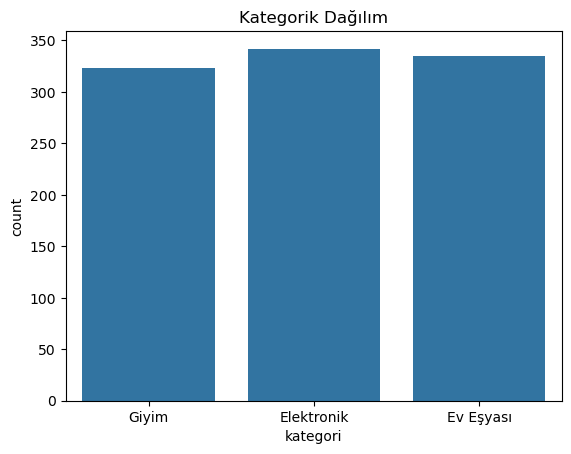

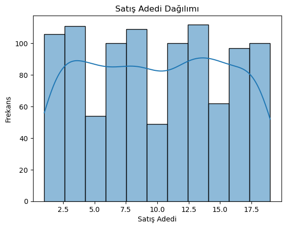

```python
import seaborn as sns
import matplotlib.pyplot as plt

# Nominal değişken için
sns.countplot(x='kategori', data=df)
plt.title("Kategorik Dağılım")
plt.show()

# Oran ölçekli değişken için
sns.histplot(df['satis_adedi'], kde=True)
plt.title("Satış Adedi Dağılımı")
plt.xlabel("Satış Adedi")
plt.ylabel("Frekans")
plt.show()
```

## 📦 Ölçek Türlerini Tanıma Pratikleri

| Ölçek Türü | Özellik | Örnek |
| --- | --- | --- |
| **Nominal** | Sadece isim | Cinsiyet, milliyet |
| **Ordinal** | Sıra var ama fark yok | Eğitim durumu, memnuniyet |
| **Interval** | Fark var ama sıfır yok | Sıcaklık, tarih |
| **Ratio** | Gerçek sıfır var, oran da var | Gelir, boy, yaş, harcama |

📌 Ratio ölçek → tüm işlemler yapılabilir  
Nominal ölçek → sadece sayılabilir

## 🧪 Gerçek Hayatta Nerelerde Görülür?

| Ölçek Türü | Senaryo |
| --- | --- |
| **Nominal** | Müşteri tipi: Bireysel, kurumsal |
| **Ordinal** | Ürün kalite skoru: düşük, orta, yüksek |
| **Interval** | Tarih: 2023, 2024, 2025 |
| **Ratio** | Satış adedi, fiyat, gelir |

📌 Bu ayrımı bilmek,  
**modellemeye yön verir.**

## 📊 Değişken Tipi ve Ölçek Türü Arasındaki Bağ

| Değişken Türü | Ölçek Türü | Açıklama |
| --- | --- | --- |
| Kategorik | Nominal | Etiket |
| Sıralı Kategorik | Ordinal | Sıra var |
| Sayısal | Interval | Sıfır mutlak değil |
| Sayısal | Ratio | Sıfır gerçek yokluktur |

📌 Bu ayrım, makine öğrenmesinde ön işleme adımlarını da belirler.

## 📋 Değişken Dönüşümü: Ölçek Değiştirme

Bazen veriyi dönüştürmek gerekir.  
Örneğin `Evet/Hayır` yerine `1/0`  
Veya `Memnuniyet: kötü, iyi, çok iyi` → `1, 2, 3`

#### Python Kodu:

```python
# Ordinal veri dönüştürme
memnuniyet_skorlari = {'Kötü': 1, 'Orta': 2, 'İyi': 3, 'Çok İyi': 4}
df1 = pd.DataFrame({'memnuniyet': ['İyi', 'Çok İyi', 'Kötü', 'Orta', 'İyi']})

df1['memnuniyet_skoru'] = df1['memnuniyet'].map(memnuniyet_skorlari)

print("Değişim sonrası ilk 5 satır:\n", df1[['memnuniyet', 'memnuniyet_skoru']].head())
```

```
Değişim sonrası ilk 5 satır:
   memnuniyet  memnuniyet_skoru
0        İyi                 3
1    Çok İyi                 4
2       Kötü                 1
3       Orta                 2
4        İyi                 3
```

📌 Bu işlem ordinal veriyi sayısal forma çevirir.  
Ama hala **oranlamada kullanılmaz.**

## 🤖 Ölçek Türü, Makine Öğrenmesi ve Modelleme Bağlantısı

| Ölçek Türü | Modelleme Uygunluğu |
| --- | --- |
| Nominal | Kodlama gerekebilir (One-Hot) |
| Ordinal | Sıralı sayısal etiketleme yapılabilir |
| Interval | Standartlaştırılabilir |
| Ratio | Doğrudan kullanılabilir |

📌 Nominal veri modelde sayıya dönüştürülmeden kullanılmaz  
Ordinal veri sıralı hale getirilirse kullanılabilir  
Interval ve ratio veriler, doğrudan istatistiksel işlemlerde kullanılır